# Airbnb Correlation Analysis

Austin Smith

26 March, 2022

# Overview

The purpose of this markdown is to run correlations between the estimated number of Airbnb listings per person in small towns across Montana and the following metrics:Median household income, Median home value, Age distribution of population; i.e. the percentage of residents under 18, between 18 and 34, etc.

I’m curious what the effect of many vs. few Airbnbs has on a small town, so I restrict my dataset to towns that have at least one Airbnb listing. I also did some manual clean-up on the datasets prior to importing them. The Airbnb search results were a bit wonky for some towns as a result of how it displays listing results and how those results change when one zooms in. For example, a few very small towns reported upwards of three listings per person in the town, which was not actually the case.

### Load Data and Visualize Basic Stats

My first step in running the correlations is to read in the data sets and gain a general understanding of what it looks like.

My best judgement, from looking at the way the Airbnb zoom tool functions, is that the average between the two zoom methods is the most accurate way to yield listings by town.

```r
# read in the data files
income_df <- read_csv('income_merged.csv')
# read in property value df
propvalue_df <- read.csv('propvalue_merged.csv')

# read in ages data; this will be cleaned up later
ages_df <- read.csv('ages_merged.csv')

# remove any towns without at least one Airbnb listing as measured by the mean of all three zoom methods or the mean of two zoom methods

pared_income_df <- income_df %>%
  filter(`3-way Mean Listings` >1,
         `Zoom - Mean Listings` >1)

pared_propvalue_df <- propvalue_df %>%
  filter(AllMeanListings >1,
         ZoomMeanListings >1)

pared_ages_df <- ages_df %>%
  filter(AllMeansRaw >1,
         ZoomMeansRaw >1)
```

```r
summary(pared_income_df$ZoomMeans)
```

```
##    Min. 1st Qu.  Median    Mean 3rd Qu.    Max.
## 0.00070 0.00550 0.01360 0.04684 0.03243 1.07890
```

```r
top_15 <- pared_income_df %>%
  top_n(15,ZoomMeans) %>%
  select(town, ZoomMeans) %>%
  rename("Listings Per Resident" = ZoomMeans)
```

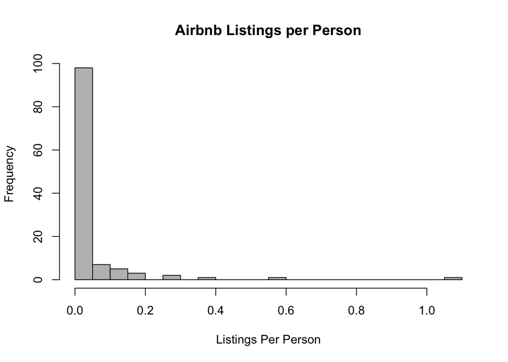

```r
hist(pared_income_df$ZoomMeans,col="gray",breaks=30,main="Airbnb Listings per Person",
     xlab="Listings Per Person",cex.main=1.2,cex.axis=1,cex.lab=1)
```

The listings per person data is extremely right skewed; many towns have very, very few listings per person while a few towns have many. (Note: I manually verified that Jardine’s data is correct).

Below, I plot median household income and median property values distributions.

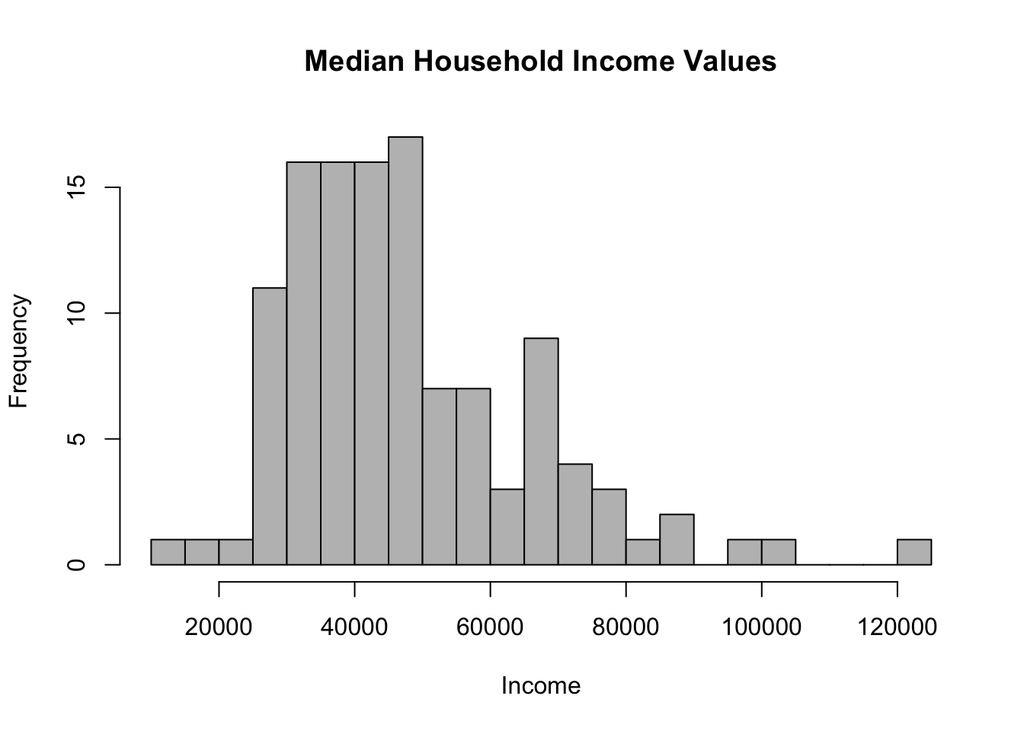

```r
# histograms of median household income and median property values

hist(pared_income_df$income_value,breaks=20,col="gray",main="Median Household Income Values",
     xlab="Income",cex.main=1.2,cex.axis=1,cex.lab=1)
```

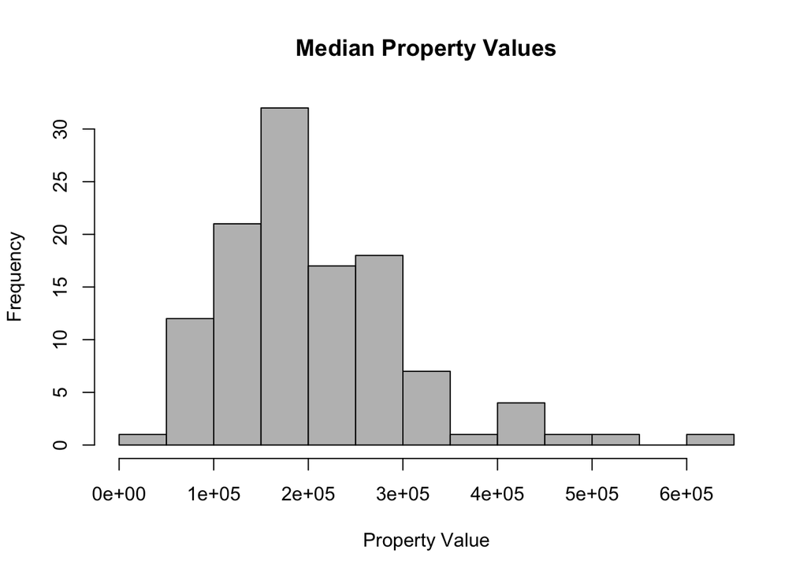

```r
hist(pared_propvalue_df$property_value,breaks=20,col="gray",main="Median Property Values",
     xlab="Property Value",cex.main=1.2,cex.axis=1,cex.lab=1)
```

Both of these distributions are also slightly right skewed, but not as badly as the listings per person. All of the variables could be log transformed to help push the distributions towards normal (note: I will do this later on).

My next task is to clean up the age related data. My current data frame has the number of residents per age band in 2019 as well as the 2019 population figures. I want to combine some age bands so each is roughly 20 years and then divide by the population so that the ages bands are expressed as a percentage of the total population. Else, larger towns would likely exhibit higher figures across all ages.

```r
# group the age band by about 20 years each

pared_ages_df <- pared_ages_df %>%
  group_by(town) %>%
  summarise("under_eighteen" = sum(num_residents[age_band=="Under 5 Years" | age_band == "5 to 17 Years"]),
            "eighteen_to_thirtyfour" = sum(num_residents[age_band=="18 to 24 Years" | age_band == "25 to 34 Years"]),
            "thirtyfive_to_fiftyfour" = sum(num_residents[age_band == "35 to 44 Years" | age_band == "45 to 54 Years"]),
            "fiftyfive_to_seventyfour" = sum(num_residents[age_band == "55 to 59 Years" | age_band == "60 & 61 Years" |age_band == "62 to 64 Years" | age_band == "65 to 74 Years"]),
            "seventyfive_plus" = sum(num_residents[age_band == "75 Years & Over"]),
            "population" = (population),
            "AllMeansRaw" = (AllMeansRaw),
            "ZoomMeansRaw" = (ZoomMeansRaw),
            "MaxListingsPerPerson" = ((Listings...No.Zoom)/(num_residents)),
            "MinListingsPerPerson" = ((Listings...Two.Zoom)/(num_residents)))
# remove the duplicate values
pared_ages_df <- distinct(pared_ages_df)

# create new columns that capture the percentage of each age band by town and the listings per person
pared_ages_df <- pared_ages_df %>%
  group_by(town) %>%
  mutate("%under_eighteen" = (under_eighteen/population),
            "%18_to_34" = (eighteen_to_thirtyfour/population),
            "%35_to_54" = (thirtyfive_to_fiftyfour/population),
            "%55_to_74" = (fiftyfive_to_seventyfour/population),
         "%75+" = (seventyfive_plus/population),
         "AllMeans" = (AllMeansRaw/population),
         "ZoomMeans" = (ZoomMeansRaw/population))

# round the percentage columns
pared_ages_df <- pared_ages_df %>%
  mutate(across(9:15, round, 3))
```

Now I will visualize histograms of all age bands in the data frame across all towns. Note that there are a few extremely small towns who report having more residents in an individual age band than total residents. I chalk this up to data fuzzing on the part of the Census. For my analysis, I will exclude towns who report 100% (or more) of their populations in any one age band.

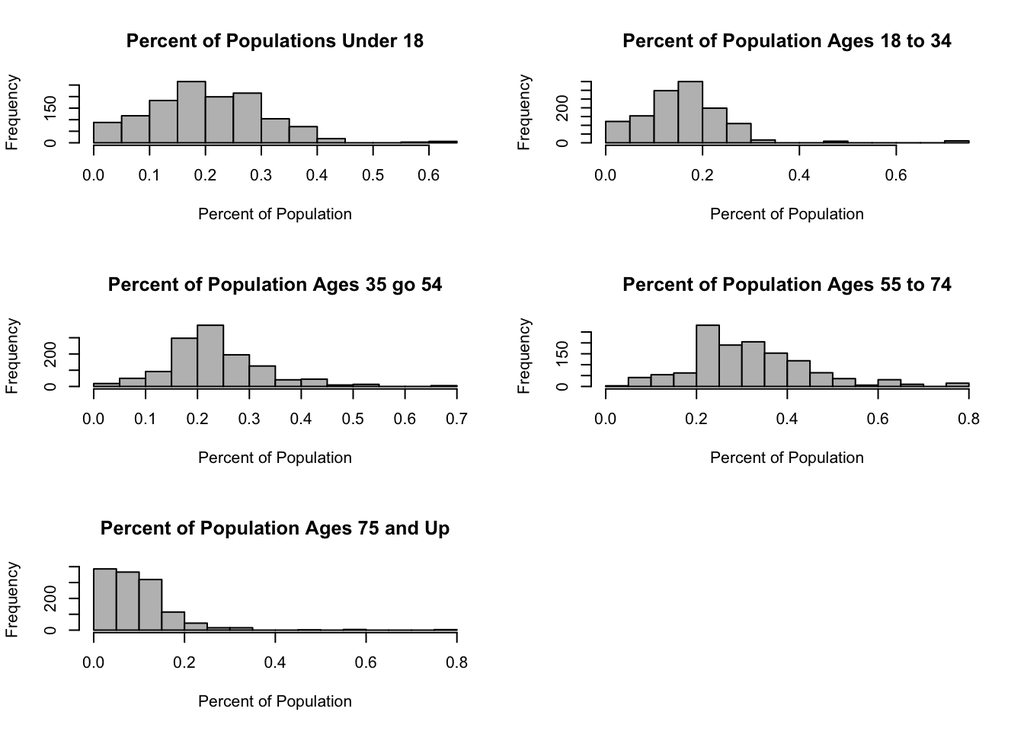

```r
# first, filter out any rows which report having 1 or greater in the percentage columns for age bands
pared_ages_df <- pared_ages_df %>%
  filter(`%under_eighteen` < 1,
          `%18_to_34` <1 ,
         `%35_to_54` < 1,
         `%55_to_74` < 1,
         `%75+` < 1
         )

# then visualize the distributions by age band
par(mfrow=c(3,2))

hist(pared_ages_df$`%under_eighteen`,breaks=20,col="gray",main="Percent of Populations Under 18",
     xlab="Percent of Population",cex.main=1.2,cex.axis=1,cex.lab=1)

hist(pared_ages_df$`%18_to_34`,breaks=20,col="gray",main="Percent of Population Ages 18 to 34",
     xlab="Percent of Population",cex.main=1.2,cex.axis=1,cex.lab=1)

hist(pared_ages_df$`%35_to_54`,breaks=20,col="gray",main="Percent of Population Ages 35 go 54",
     xlab="Percent of Population",cex.main=1.2,cex.axis=1,cex.lab=1)

hist(pared_ages_df$`%55_to_74`,breaks=20,col="gray",main="Percent of Population Ages 55 to 74",
     xlab="Percent of Population",cex.main=1.2,cex.axis=1,cex.lab=1)

hist(pared_ages_df$`%75+`,breaks=20,col="gray",main="Percent of Population Ages 75 and Up",
     xlab="Percent of Population",cex.main=1.2,cex.axis=1,cex.lab=1)
```

Each of these distributions are also right skewed, though populations under 18 and between 35 adn 54 are much less skewed than the other cohorts.

### Correlation Analysis Assumptions Test

There are five assumptions that must be met in order to run a valid Pearson’s correlation.

1. The two variables should be measured at the interval or ratio level; all of my variables meet this assumption.
2. There should be a linear relationship between the two variables; below, I will visualize scatterplots of my data to determine if this assumption is met.
3. Both variables should be normally distributed; this is not the case unless I log transform the variables.
4. Each observation in the dataset should have a pair of values; this is the case, because each of my rows of data applies to a single town.
5. There should be no extreme outliers in the dataset; I will determine if this is the case via the scatterplots below.

For a Spearman’s correlation, which ranks the data piror to doing the correlation, the data does not need to be normally distributed, though it should meet the #1 and #4 assumptions above. This method is robust to outliers and it assumes a monotonic relationship between the variables.

As will be seen in the visualizations below, neither of the correlation methods is a perfect fit for the data, but I judge that the assumptions are sufficiently met to run both analyses. I will conduct both correlations later on.

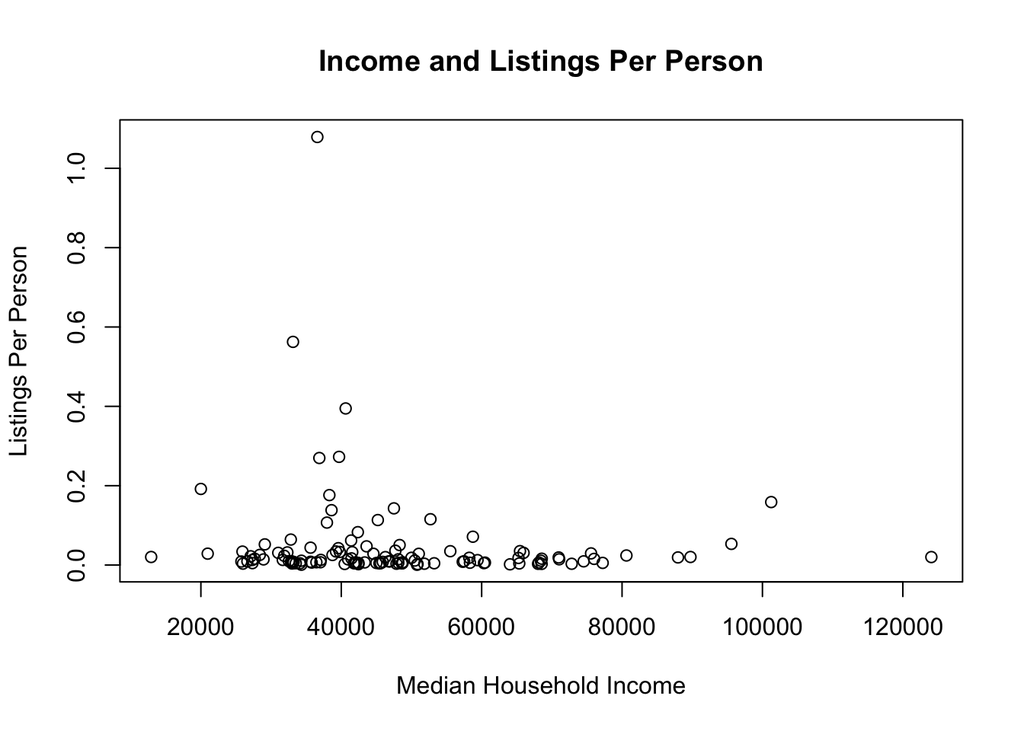

```r
# scatter plots of the income and property values and listings per person below, respectively

plot((ZoomMeans)~(income_value),data=pared_income_df,main = "Income and Listings Per Person", xlab="Median Household Income", ylab = "Listings Per Person")
```

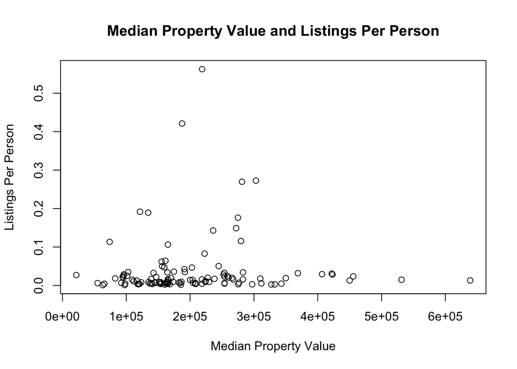

```r
plot((ZoomMeans)~(property_value),data=pared_propvalue_df,main = "Median Property Value and Listings Per Person", xlab="Median Property Value", ylab = "Listings Per Person")
```

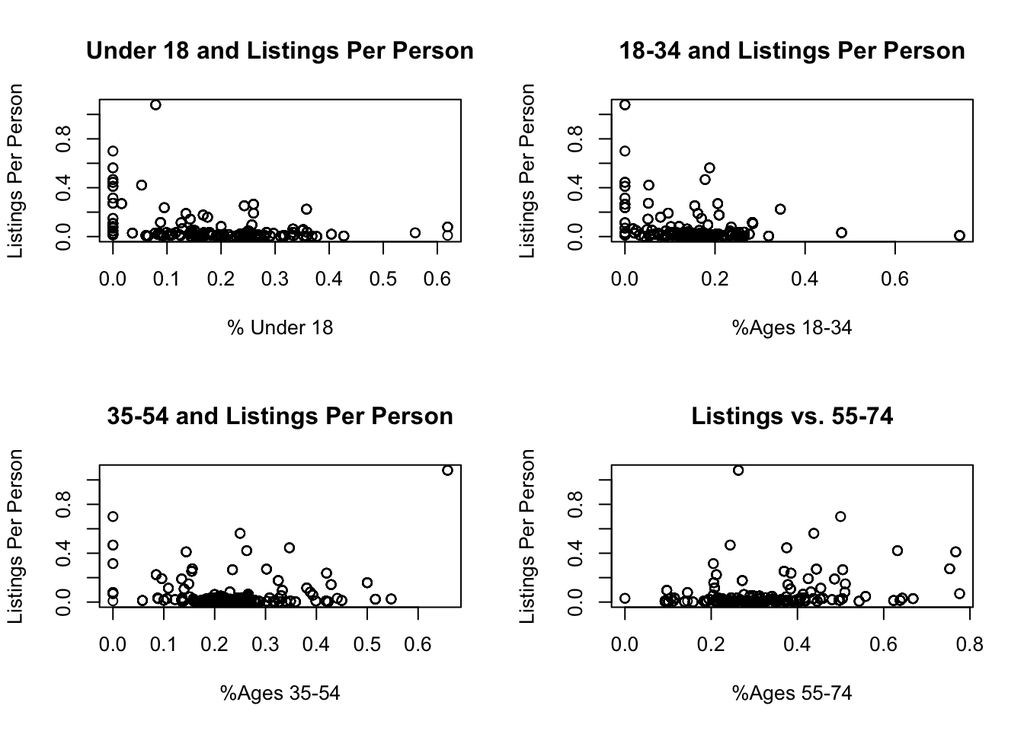

```r
# scatter plots of the Zoom mean listing methods and all of the age bands plotted below
par(mfrow=c(2,2))

plot(ZoomMeans~`%under_eighteen`,data=pared_ages_df,main = "Under 18 and Listings Per Person", xlab="% Under 18", ylab = "Listings Per Person")

plot(ZoomMeans~`%18_to_34`,data=pared_ages_df,main = "18-34 and Listings Per Person", xlab="%Ages 18-34", ylab = "Listings Per Person")

plot(ZoomMeans~`%35_to_54`,data=pared_ages_df,main = "35-54 and Listings Per Person", xlab="%Ages 35-54", ylab = "Listings Per Person")

plot(ZoomMeans~`%55_to_74`,data=pared_ages_df,main = "Listings vs. 55-74", xlab="%Ages 55-74", ylab = "Listings Per Person")
```

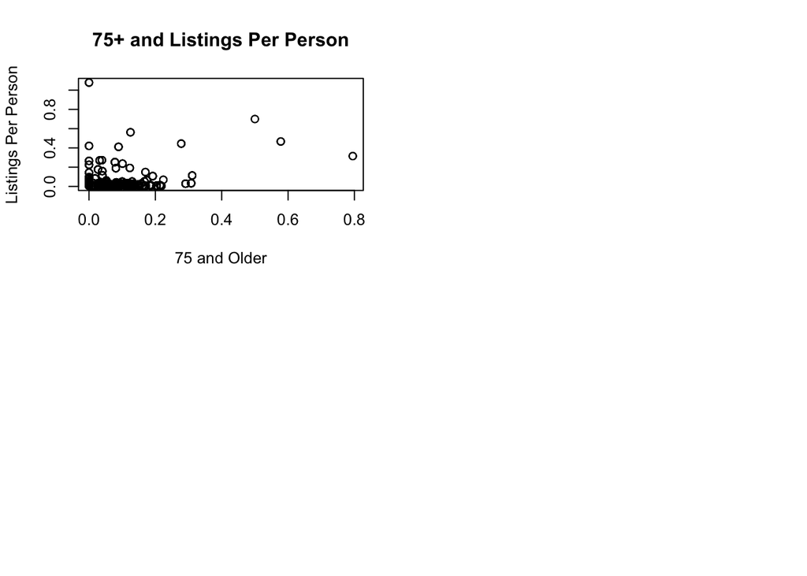

```r
plot(ZoomMeans~`%75+`,data=pared_ages_df,main = "75+ and Listings Per Person", xlab="75 and Older", ylab = "Listings Per Person")
```

There are so many towns with very, very few listings that the non-transformed relationships do not appear to exist - or, at least, are not very linear or monotonic.

### Spearman’s Rank Correlation Analysis

Unlike Pearson’s correlation, Spearman’s correlation analysis does not assume normality and is robust to outliers. Because my data has outliers and is not normally distributed, a rank correlation is a more appropriate test than Pearson’s linear correlation when the data is not transformed. The Spearman correlation measures the monotonic relationship of the variables rather than the linear association of the variables, so it is more reliable with non-linear data.

```r
# run Spearman's correlations for listings per person and income

sp_incomeZoomMeans <- cor.test(pared_income_df$ZoomMeans, pared_income_df$income_value, method = 'spearman')
sp_incomeZoomMeans
```

```
##
##  Spearman's rank correlation rho
##
## data:  pared_income_df$ZoomMeans and pared_income_df$income_value
## S = 306151, p-value = 0.2029
## alternative hypothesis: true rho is not equal to 0
## sample estimates:
##        rho
## -0.1180779
```

The Spearman’s correlation for income and listings per person is not statistically significant.

```r
# run Spearman's correlations for listings per person and property values

sp_propZoomMeans <- cor.test(pared_propvalue_df$ZoomMeans, pared_propvalue_df$property_value, method = 'spearman')
sp_propZoomMeans
```

```
##
##  Spearman's rank correlation rho
##
## data:  pared_propvalue_df$ZoomMeans and pared_propvalue_df$property_value
## S = 216713, p-value = 0.07334
## alternative hypothesis: true rho is not equal to 0
## sample estimates:
##       rho
## 0.1669047
```

The Spearman’s correlation between listings per person and property values is also not significant.

```r
# run Spearman's correlations for listings per person and the percent of the population under 18

sp_under18ZoomMeans <- cor.test(pared_ages_df$ZoomMeans, pared_ages_df$`%under_eighteen`, method = 'spearman')
sp_under18ZoomMeans
```

```
##
##  Spearman's rank correlation rho
##
## data:  pared_ages_df$ZoomMeans and pared_ages_df$`%under_eighteen`
## S = 450624671, p-value < 2.2e-16
## alternative hypothesis: true rho is not equal to 0
## sample estimates:
##        rho
## -0.3261991
```

Spearman’s correlation between listings per person and the percent of the population under 18 are moderately, negatively correlated and statistically significant.

```r
# run Spearman's correlations for listings per person and the percent of the population 18-34 and then 35 to 54, 55-74, and over 75

#18-34 age band
sp_18to34ZoomMeans <- cor.test(pared_ages_df$ZoomMeans, pared_ages_df$`%18_to_34`, method = 'spearman')
sp_18to34ZoomMeans
```

```
##
##  Spearman's rank correlation rho
##
## data:  pared_ages_df$ZoomMeans and pared_ages_df$`%18_to_34`
## S = 429180848, p-value < 2.2e-16
## alternative hypothesis: true rho is not equal to 0
## sample estimates:
##        rho
## -0.2630894
```

```r
# 35-54 age cohort
sp_35to54ZoomMeans <- cor.test(pared_ages_df$ZoomMeans, pared_ages_df$`%35_to_54`, method = 'spearman')
sp_35to54ZoomMeans
```

```
##
##  Spearman's rank correlation rho
##
## data:  pared_ages_df$ZoomMeans and pared_ages_df$`%35_to_54`
## S = 351392867, p-value = 0.2242
## alternative hypothesis: true rho is not equal to 0
## sample estimates:
##         rho
## -0.03415754
```

```r
# 55-74 age cohort
sp_55to74ZoomMeans <- cor.test(pared_ages_df$ZoomMeans, pared_ages_df$`%55_to_74`, method = 'spearman')
sp_55to74ZoomMeans
```

```
##
##  Spearman's rank correlation rho
##
## data:  pared_ages_df$ZoomMeans and pared_ages_df$`%55_to_74`
## S = 221859056, p-value < 2.2e-16
## alternative hypothesis: true rho is not equal to 0
## sample estimates:
##       rho
## 0.3470635
```

```r
# 75+ age cohort
sp_74andoverZoomMeans <- cor.test(pared_ages_df$ZoomMeans, pared_ages_df$`%75+`, method = 'spearman')
sp_74andoverZoomMeans
```

```
##
##  Spearman's rank correlation rho
##
## data:  pared_ages_df$ZoomMeans and pared_ages_df$`%75+`
## S = 376109660, p-value = 0.0001369
## alternative hypothesis: true rho is not equal to 0
## sample estimates:
##        rho
## -0.1068996
```

Listings per person and the percentage of the population between 18 and 34 years old are weakly, negatively correlated and statistically significant.

There is no significant correlation between listings per person and the percentage of the population ages 35 to 54.

The correlation between listings per person and the percentage of the population ages 55 to 74 is moderate and positive, and statistically significant.

The relationship between listings per person and the percentage of the population 75 and older is very weakly negative and statistically significant.

So, there are statistically significant correlative relationships between listings per person and the following variables: 1. The percent of the population under 18: moderate, negative relationship 2. The percent of the population between ages 18 and 34: weak, negative relationship 3. The percent of the population between ages 55 and 74: moderate, positive relationship 4. The percent of the population ages 75 and over: very weak, negative relationship

These findings support the idea that Airbnb listings are associated with fewer young people in a populace, fewer families of child-bearing age, and more older/established age cohorts who may have owned homes before Airbnb became an influence.

### Visualize the Results of the Spearman’s Correlations

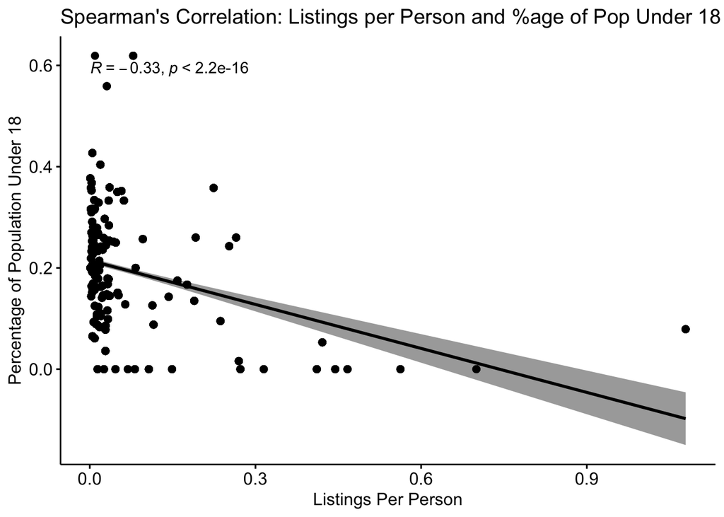

```r
# plot of the correlation between listings and % of pop under 18

ggscatter(pared_ages_df, x = "ZoomMeans", y = "%under_eighteen",
          add = "reg.line", conf.int = TRUE,
          cor.coef = TRUE, cor.method = "spearman",
          xlab = "Listings Per Person", ylab = "Percentage of Population Under 18", main = "Spearman's Correlation: Listings per Person and %age of Pop Under 18")
```

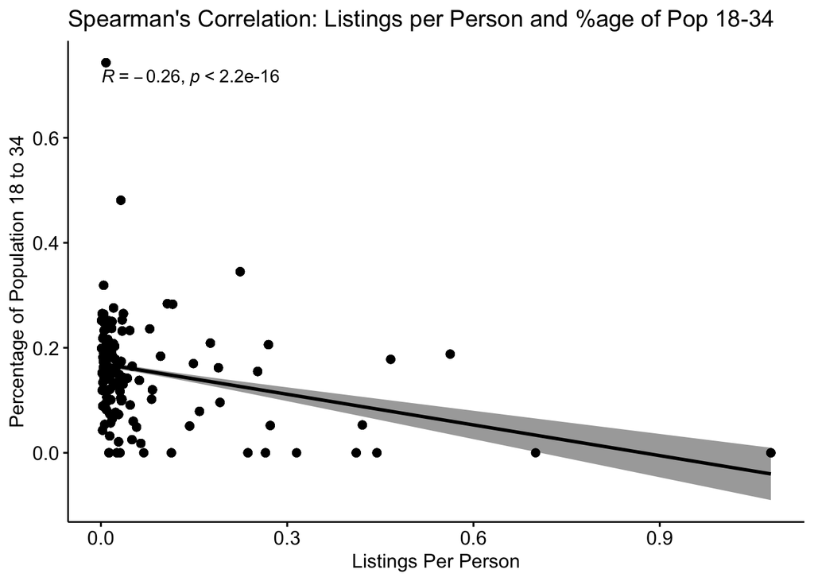

```r
# plot of the correlation between listings and % of pop 18 to 34

ggscatter(pared_ages_df, x = "ZoomMeans", y = "%18_to_34",
          add = "reg.line", conf.int = TRUE,
          cor.coef = TRUE, cor.method = "spearman",
          xlab = "Listings Per Person", ylab = "Percentage of Population 18 to 34", main = "Spearman's Correlation: Listings per Person and %age of Pop 18-34")
```

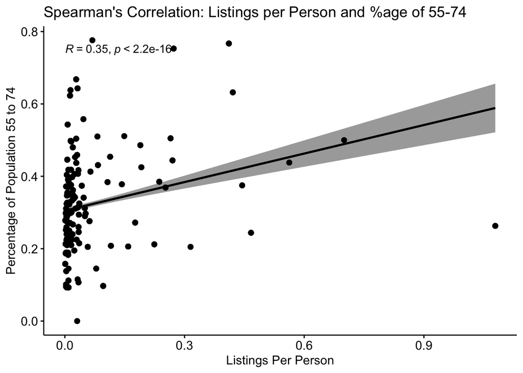

```r
# plot of the correlation between listings and % of pop ages 55 to 74

ggscatter(pared_ages_df, x = "ZoomMeans", y = "%55_to_74",
          add = "reg.line", conf.int = TRUE,
          cor.coef = TRUE, cor.method = "spearman",
          xlab = "Listings Per Person", ylab = "Percentage of Population 55 to 74", main = "Spearman's Correlation: Listings per Person and %age of 55-74")
```

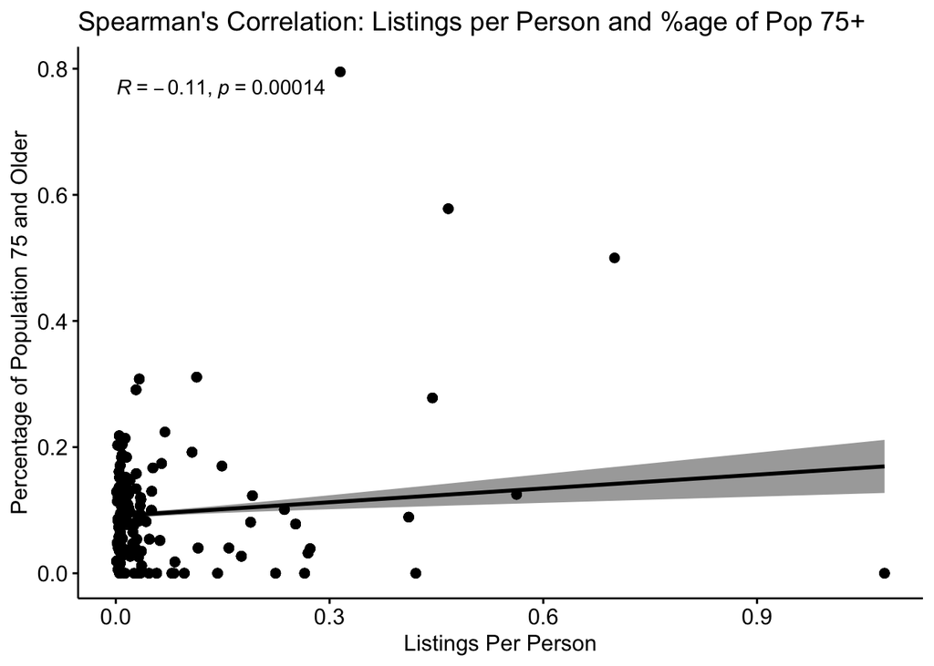

```r
# plot of the correlation between listings and % of pop ages 75+

ggscatter(pared_ages_df, x = "ZoomMeans", y = "%75+",
          add = "reg.line", conf.int = TRUE,
          cor.coef = TRUE, cor.method = "spearman",
          xlab = "Listings Per Person", ylab = "Percentage of Population 75 and Older", main = "Spearman's Correlation: Listings per Person and %age of Pop 75+")
```

### Pearson’s Correlations

As a final test, I will log transform the variables and take the Pearson’s correlations. The log transformation will make the distributions of the variables more normal (as visualized below). The scatter plots of the log transformed variables (also pictured below) are not exactly linear, but they do seem to show a degree of linear relationships. So, these correlation results should be understood with that in mind: the data does not perfectly pass the assumptions for a valid Pearson’s correlation, but they are not so far off as to make the test invalid.

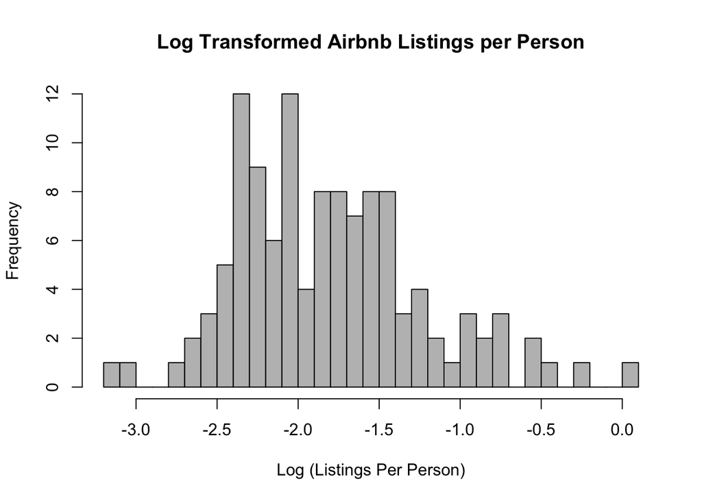

```r
# distribution of log transformed listings per person
hist(log10(pared_income_df$ZoomMeans),col="gray",breaks=30,main="Log Transformed Airbnb Listings per Person",
     xlab="Log (Listings Per Person)",cex.main=1.2,cex.axis=1,cex.lab=1)
```

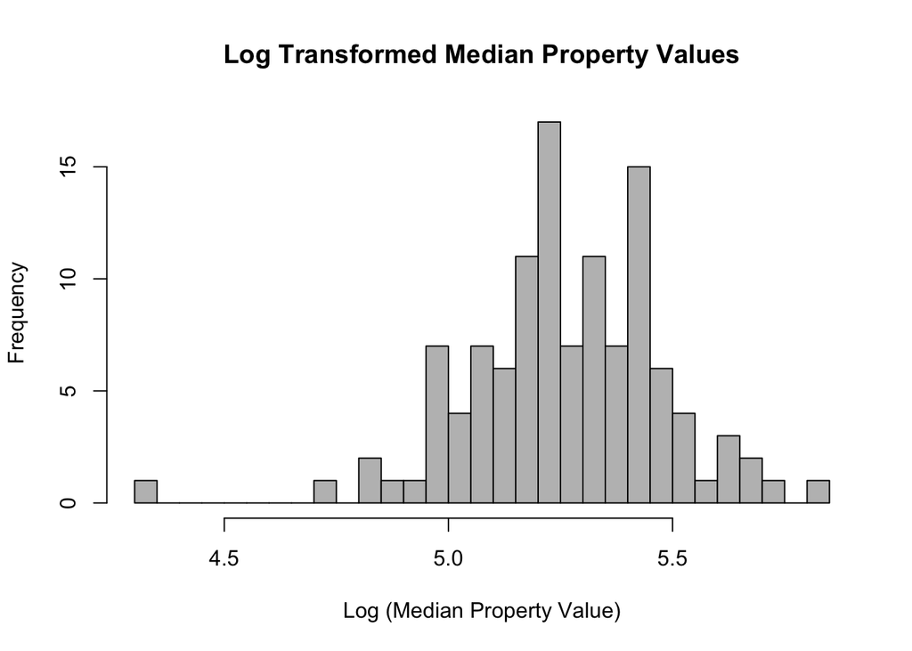

```r
# distribution of log transformed property values
hist(log10(pared_propvalue_df$property_value),col="gray",breaks=30,main="Log Transformed Median Property Values",
     xlab="Log (Median Property Value)",cex.main=1.2,cex.axis=1,cex.lab=1)
```

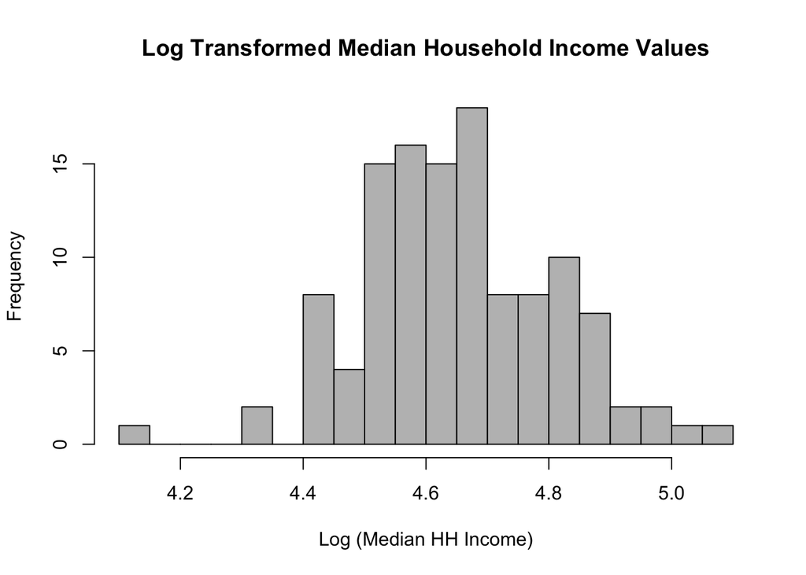

```r
# distribution of log transformed median HH incomes
hist(log10(pared_income_df$income_value),col="gray",breaks=30,main="Log Transformed Median Household Income Values",
     xlab="Log (Median HH Income)",cex.main=1.2,cex.axis=1,cex.lab=1)
```

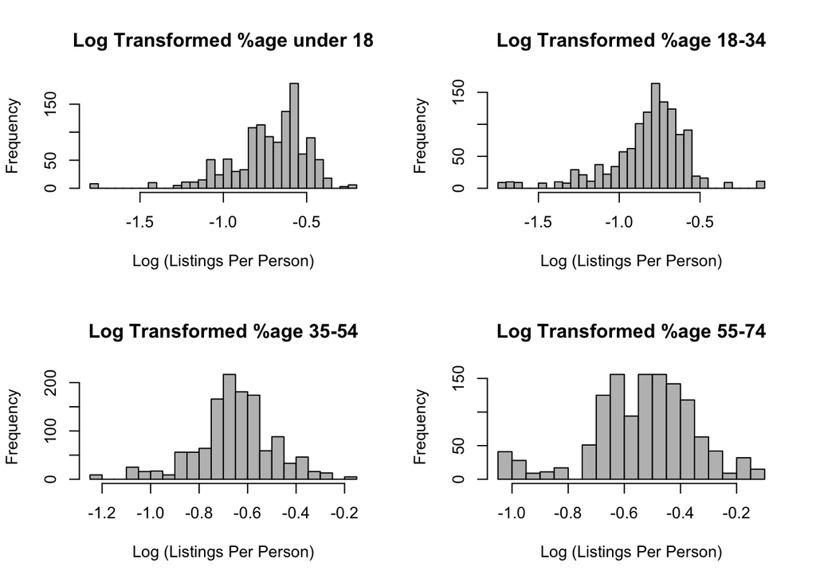

```r
par(mfrow=c(2,2))
# log transformed % under 18 values
hist(log10(pared_ages_df$`%under_eighteen`),col="gray",breaks=30,main="Log Transformed %age under 18",
     xlab="Log (Listings Per Person)",cex.main=1.2,cex.axis=1,cex.lab=1)

# log transformed % 18-34
hist(log10(pared_ages_df$`%18_to_34`),col="gray",breaks=30,main="Log Transformed %age 18-34",
     xlab="Log (Listings Per Person)",cex.main=1.2,cex.axis=1,cex.lab=1)

# log transformed % 35-54
hist(log10(pared_ages_df$`%35_to_54`),col="gray",breaks=30,main="Log Transformed %age 35-54",
     xlab="Log (Listings Per Person)",cex.main=1.2,cex.axis=1,cex.lab=1)

# log transformed % 55-74
hist(log10(pared_ages_df$`%55_to_74`),col="gray",breaks=30,main="Log Transformed %age 55-74",
     xlab="Log (Listings Per Person)",cex.main=1.2,cex.axis=1,cex.lab=1)
```

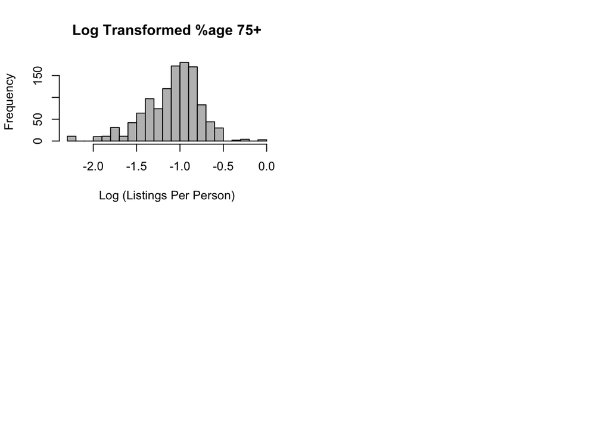

```r
# log transformed % 55-74
hist(log10(pared_ages_df$`%75+`),col="gray",breaks=30,main="Log Transformed %age 75+",
     xlab="Log (Listings Per Person)",cex.main=1.2,cex.axis=1,cex.lab=1)
```

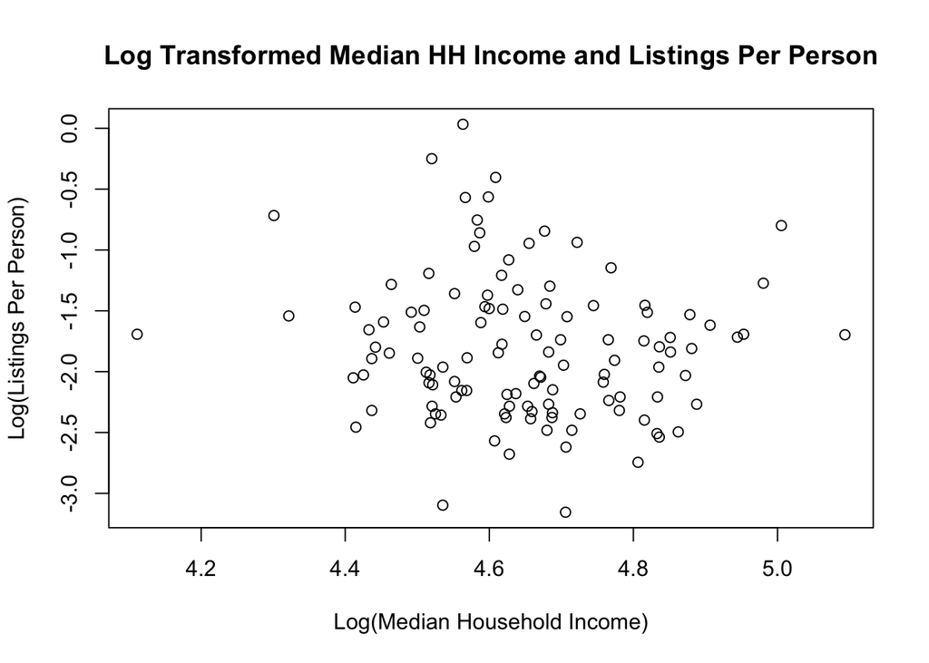

```r
# log transformed listings vs. income
plot(log10(ZoomMeans)~(log10(income_value)),data=pared_income_df,main = "Log Transformed Median HH Income and Listings Per Person", xlab="Log(Median Household Income)", ylab = "Log(Listings Per Person)")
```

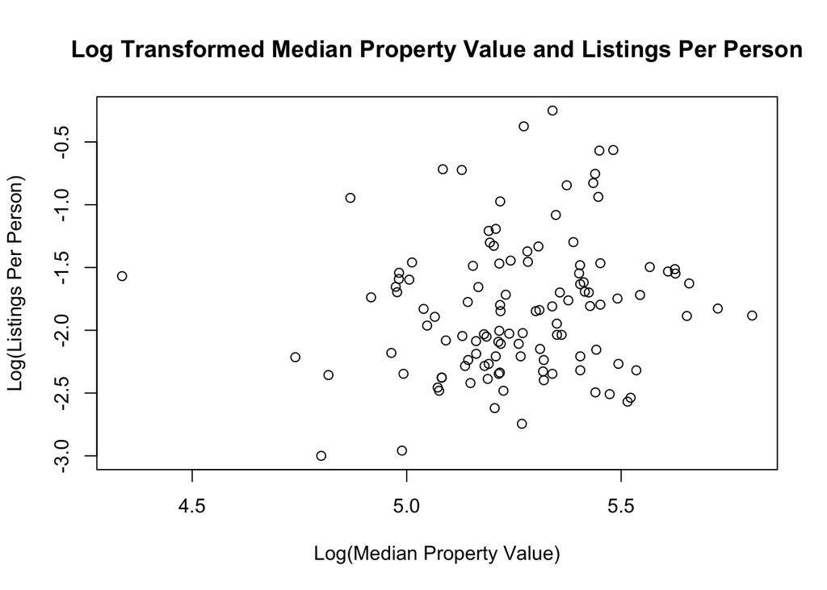

```r
# log transformed listings vs. property values
plot(log10(ZoomMeans)~(log10(property_value)),data=pared_propvalue_df,main = "Log Transformed Median Property Value and Listings Per Person", xlab="Log(Median Property Value)", ylab = "Log(Listings Per Person)")
```

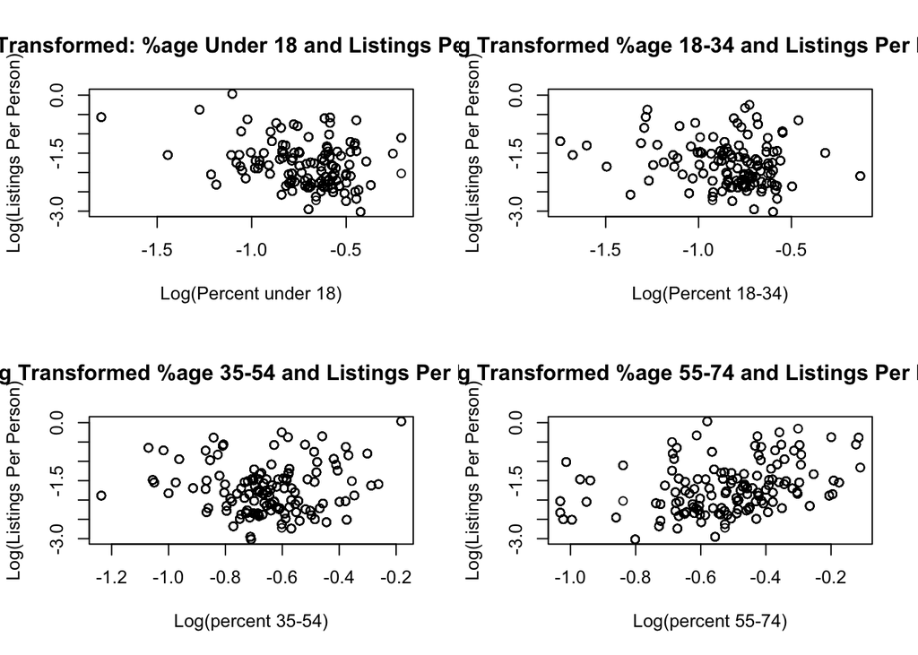

```r
par(mfrow=c(2,2))
# log transformed listings vs. log transformed under 18
plot(log10(ZoomMeans)~(log10(`%under_eighteen`)),data=pared_ages_df,main = "Log Transformed: %age Under 18 and Listings Per Person", xlab="Log(Percent under 18)", ylab = "Log(Listings Per Person)")

# log transformed listings vs. 18-34
plot(log10(ZoomMeans)~(log10(`%18_to_34`)),data=pared_ages_df,main = "Log Transformed %age 18-34 and Listings Per Person", xlab="Log(Percent 18-34)", ylab = "Log(Listings Per Person)")

# log transformed listings vs. 35-54
plot(log10(ZoomMeans)~(log10(`%35_to_54`)),data=pared_ages_df,main = "Log Transformed %age 35-54 and Listings Per Person", xlab="Log(percent 35-54)", ylab = "Log(Listings Per Person)")

# log transformed listings vs. 55-74
plot(log10(ZoomMeans)~(log10(`%55_to_74`)),data=pared_ages_df,main = "Log Transformed %age 55-74 and Listings Per Person", xlab="Log(percent 55-74)", ylab = "Log(Listings Per Person)")
```

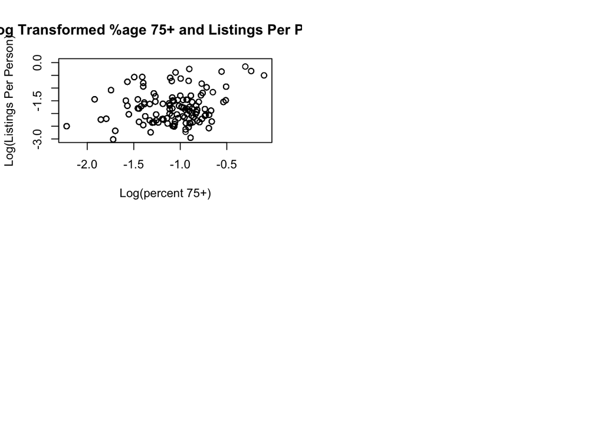

```r
# log transformed listings vs. 75+
plot(log10(ZoomMeans)~(log10(`%75+`)),data=pared_ages_df,main = "Log Transformed %age 75+ and Listings Per Person", xlab="Log(percent 75+)", ylab = "Log(Listings Per Person)")
```

Now I will run the Pearson’s correlations on the transformed variables.

```r
# first, add columns to the data frames that are the log transformations.

pared_income_df <- pared_income_df %>%
  mutate(loglistings = log10(ZoomMeans),
         logincome = log10(income_value))

pared_propvalue_df <- pared_propvalue_df %>%
  mutate(loglistings = log10(ZoomMeans),
         logprop = log10(property_value))

# note that I need to filter out 0, which results in -Inf log transformations
pared_ages_df <- pared_ages_df %>%
  mutate(loglistings = log10(ZoomMeans),
         logunder18 = log10(`%under_eighteen`),
         log18_34 = log10(`%18_to_34`),
         log35_54 = log10(`%35_to_54`),
         log55_74 = log10(`%55_to_74`),
         log75_plus = log10(`%75+`)) %>%
  filter(`%under_eighteen` != 0,
        `%18_to_34` != 0,
        `%35_to_54` != 0,
         `%55_to_74` != 0,
         `%75+` != 0)

# then run the Pearson's correlations
# household income
pe_incomeZoomMeans <- cor.test(pared_income_df$loglistings,pared_income_df$logincome, method = 'pearson')
pe_incomeZoomMeans
```

```
##
##  Pearson's product-moment correlation
##
## data:  pared_income_df$loglistings and pared_income_df$logincome
## t = -1.0491, df = 116, p-value = 0.2963
## alternative hypothesis: true correlation is not equal to 0
## 95 percent confidence interval:
##  -0.2729259  0.0853048
## sample estimates:
##         cor
## -0.09694948
```

```r
# property value
pe_propZoomMeans <- cor.test(pared_propvalue_df$loglistings, pared_propvalue_df$logprop, method = 'pearson')
pe_propZoomMeans
```

```
##
##  Pearson's product-moment correlation
##
## data:  pared_propvalue_df$loglistings and pared_propvalue_df$logprop
## t = 1.6, df = 114, p-value = 0.1124
## alternative hypothesis: true correlation is not equal to 0
## 95 percent confidence interval:
##  -0.03506195  0.32182307
## sample estimates:
##      cor
## 0.148202
```

```r
# under 18 age band
pe_under18ZoomMeans <- cor.test(pared_ages_df$loglistings, pared_ages_df$logunder18, method = 'pearson')
pe_under18ZoomMeans
```

```
##
##  Pearson's product-moment correlation
##
## data:  pared_ages_df$loglistings and pared_ages_df$logunder18
## t = -10.568, df = 1081, p-value < 2.2e-16
## alternative hypothesis: true correlation is not equal to 0
## 95 percent confidence interval:
##  -0.3590219 -0.2510030
## sample estimates:
##       cor
## -0.305997
```

```r
#18-34 age band
pe_18to34ZoomMeans <- cor.test(pared_ages_df$loglistings, pared_ages_df$log18_34, method = 'pearson')
pe_18to34ZoomMeans
```

```
##
##  Pearson's product-moment correlation
##
## data:  pared_ages_df$loglistings and pared_ages_df$log18_34
## t = -6.9373, df = 1081, p-value = 6.872e-12
## alternative hypothesis: true correlation is not equal to 0
## 95 percent confidence interval:
##  -0.2627890 -0.1487113
## sample estimates:
##        cor
## -0.2064517
```

```r
# 35-54 age cohort
pe_35to54ZoomMeans <- cor.test(pared_ages_df$loglistings, pared_ages_df$log35_54, method = 'pearson')
pe_35to54ZoomMeans
```

```
##
##  Pearson's product-moment correlation
##
## data:  pared_ages_df$loglistings and pared_ages_df$log35_54
## t = -1.458, df = 1081, p-value = 0.1451
## alternative hypothesis: true correlation is not equal to 0
## 95 percent confidence interval:
##  -0.10359864  0.01530674
## sample estimates:
##         cor
## -0.04430285
```

```r
# 55-74 age cohort
pe_55to74ZoomMeans <- cor.test(pared_ages_df$loglistings, pared_ages_df$log55_74, method = 'pearson')
pe_55to74ZoomMeans
```

```
##
##  Pearson's product-moment correlation
##
## data:  pared_ages_df$loglistings and pared_ages_df$log55_74
## t = 10.949, df = 1081, p-value < 2.2e-16
## alternative hypothesis: true correlation is not equal to 0
## 95 percent confidence interval:
##  0.2613072 0.3685900
## sample estimates:
##       cor
## 0.3159582
```

```r
# 75+ age cohort
pe_75plusZoomMeans <- cor.test(pared_ages_df$loglistings, pared_ages_df$log75_plus, method = 'pearson')
pe_75plusZoomMeans
```

```
##
##  Pearson's product-moment correlation
##
## data:  pared_ages_df$loglistings and pared_ages_df$log75_plus
## t = -0.70521, df = 1081, p-value = 0.4808
## alternative hypothesis: true correlation is not equal to 0
## 95 percent confidence interval:
##  -0.08090993  0.03817386
## sample estimates:
##        cor
## -0.0214441
```

### Visualize the Results of the Pearson’s Correlations

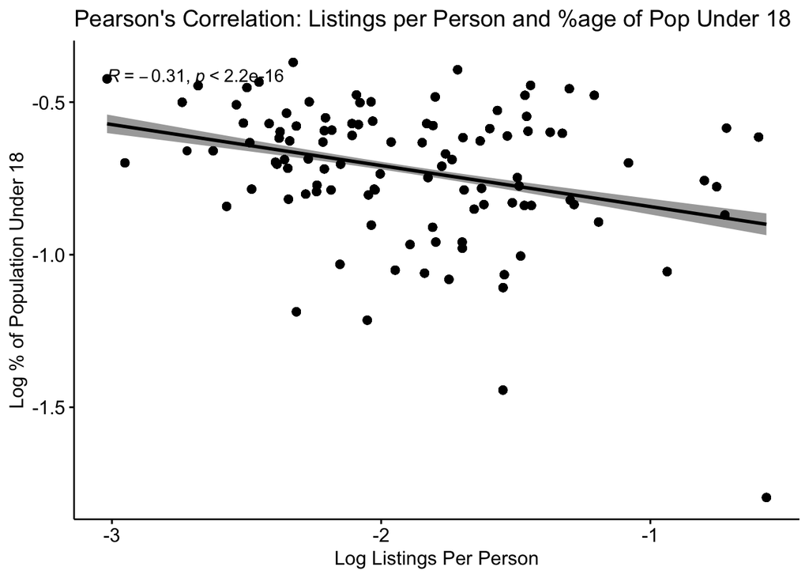

```r
# plot of the correlation between listings and % of pop under 18

ggscatter(pared_ages_df, x = "loglistings", y = "logunder18",
          add = "reg.line", conf.int = TRUE,
          cor.coef = TRUE, cor.method = "pearson",
          xlab = "Log Listings Per Person", ylab = "Log % of Population Under 18", main = "Pearson's Correlation: Listings per Person and %age of Pop Under 18")
```

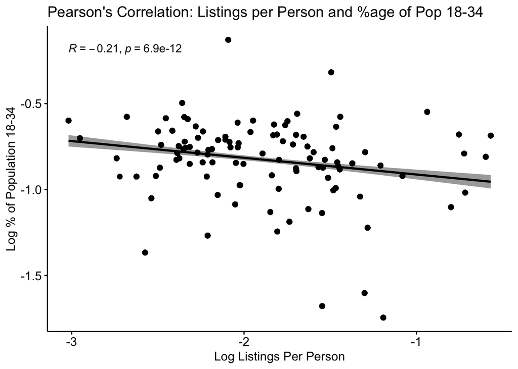

```r
ggscatter(pared_ages_df, x = "loglistings", y = "log18_34",
          add = "reg.line", conf.int = TRUE,
          cor.coef = TRUE, cor.method = "pearson",
          xlab = "Log Listings Per Person", ylab = "Log % of Population 18-34", main = "Pearson's Correlation: Listings per Person and %age of Pop 18-34")
```

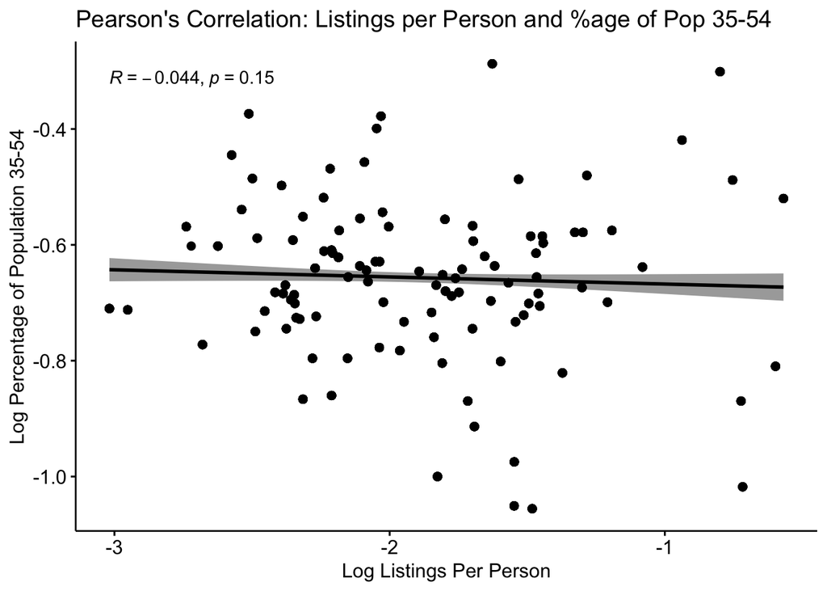

```r
ggscatter(pared_ages_df, x = "loglistings", y = "log35_54",
          add = "reg.line", conf.int = TRUE,
          cor.coef = TRUE, cor.method = "pearson",
          xlab = "Log Listings Per Person", ylab = "Log Percentage of Population 35-54", main = "Pearson's Correlation: Listings per Person and %age of Pop 35-54")
```

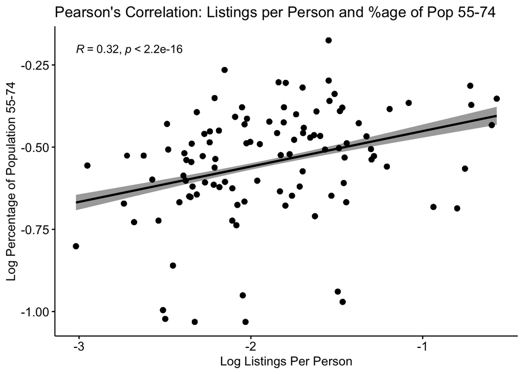

```r
ggscatter(pared_ages_df, x = "loglistings", y = "log55_74",
          add = "reg.line", conf.int = TRUE,
          cor.coef = TRUE, cor.method = "pearson",
          xlab = "Log Listings Per Person", ylab = "Log Percentage of Population 55-74", main = "Pearson's Correlation: Listings per Person and %age of Pop 55-74")
```

```r
# export data frames to csv
write.csv(pared_income_df,"pared_income.csv", row.names = FALSE)
write.csv(pared_propvalue_df,"pared_propvalue.csv", row.names = FALSE)
write.csv(pared_ages_df,"pared_ages.csv", row.names = FALSE)
```